# Godard - Coman PFE : Analysis of the relationship between Oil Price and the EU27 Economy, 1995 - 2021

```python
from dateutil.parser import parse
import matplotlib as mpl
import matplotlib.pyplot as plt
import seaborn as sns
import numpy as np
import pandas as pd
%matplotlib inline

from statsmodels.tsa.api import VAR
from statsmodels.tsa.stattools import adfuller
from statsmodels.tools.eval_measures import rmse, aic
from statsmodels.tsa.vector_ar.irf import IRAnalysis
```

## 1: Import Raw Data and Oil Price Treatment

```python
#The Raw Data:
brent_monthly = pd.read_csv('https://raw.githubusercontent.com/vladco97/PFE-Godard-Coman/main/data/brent-monthly_csv.csv')
eu_economy = pd.read_csv('https://raw.githubusercontent.com/vladco97/PFE-Godard-Coman/main/EU27%20Economy/namq_10_gdp__custom_1561076_page_linear.csv')
eu_unemployment = pd.read_csv('https://raw.githubusercontent.com/vladco97/PFE-Godard-Coman/main/Ch%C3%B4mage%20UE%20-%20Feuille%201.csv')
```

```python
#First we build the GDP TimeSeries for it to be linkable homogeneous and linkable to the reste of the Data:
brent_monthly['Date'] = pd.to_datetime(brent_monthly['Date'])
brent_quarterly = brent_monthly.groupby(pd.PeriodIndex(brent_monthly['Date'], freq='Q')).Price.mean()
brent_quarterly = brent_quarterly.to_frame(name='brent_price_dollars')
```

## 2: EU 27 GDP Treatment & Cleaning

```python
#First we build the EU27 GDP TimeSeries for it to be homogeneous and linkable to the rest of the Data:
eu_gdp_market_price = eu_economy[eu_economy['na_item'] == 'B1GQ']
eu_gdp_market_price = eu_gdp_market_price[['TIME_PERIOD', 'OBS_VALUE']]
eu_gdp_market_price.rename(columns={'TIME_PERIOD':'Date', 'OBS_VALUE' : 'eu_gdp_market_price'}, inplace=True)
eu_gdp_market_price.Date = pd.to_datetime(eu_gdp_market_price.Date)
eu_gdp_market_price.Date = pd.PeriodIndex(eu_gdp_market_price['Date'], freq='Q')
eu_gdp_market_price.set_index(['Date'], inplace=True)

#We then link the first two TimeSeries in an intermediate table that will be used to build our Main DataSet
eu_gdp_and_brent = eu_gdp_market_price.join(brent_quarterly, how='left', sort=True)
eu_gdp_and_brent['gdp_billion_euros'] = eu_gdp_and_brent.eu_gdp_market_price / 1000
eu_gdp_and_brent.drop(['eu_gdp_market_price'], axis=1, inplace=True)
```

## 3: Gross Capital Formation Treatment & Cleaning

```python
#Here we build the Gross Capital Formation TimeSeries for it to be homogeneous and linkable to the rest of the Data:
gross_cap_formation = eu_economy[eu_economy['na_item'] == 'P5G']
gross_cap_formation = gross_cap_formation[['TIME_PERIOD', 'OBS_VALUE']]
gross_cap_formation.rename(columns={'TIME_PERIOD':'Date', 'OBS_VALUE' : 'gross_cap_formation'}, inplace=True)
gross_cap_formation.Date = pd.to_datetime(gross_cap_formation.Date)
gross_cap_formation.Date = pd.PeriodIndex(gross_cap_formation['Date'], freq='Q')
gross_cap_formation.set_index(['Date'], inplace=True)
```

## 4: Wages & Salaries Treatment & Cleaning

```python
#Here we build the Gross Capital Formation TimeSeries for it to be homogeneous and linkable to the rest of the Data:
wages_and_sal = eu_economy[eu_economy['na_item'] == 'D11']
wages_and_sal = wages_and_sal[['TIME_PERIOD', 'OBS_VALUE']]
wages_and_sal.rename(columns={'TIME_PERIOD':'Date', 'OBS_VALUE' : 'wages_and_sal'}, inplace=True)
wages_and_sal.Date = pd.to_datetime(wages_and_sal.Date)
wages_and_sal.Date = pd.PeriodIndex(wages_and_sal['Date'], freq='Q')
wages_and_sal.set_index(['Date'], inplace=True)
```

## 5: Joining of all parts to make the Main DataFrame

This final part gives us the Data frame that we shall use for retreatment, analysis and forecasts.

```python
#Finally, The last joins give us our final working Data:
DATA = eu_gdp_and_brent.join(gross_cap_formation, how='left', sort=True)
DATA = DATA.join(wages_and_sal, how='left', sort=True)

#Converting the Quarterly Index into a cleaner Date Type for better graph display:
DATA['newdate'] = DATA.index.to_timestamp()
DATA.set_index(['newdate'], inplace=True)
DATA
```

| newdate | brent_price_dollars | gdp_billion_euros | gross_cap_formation | wages_and_sal |
| --- | --- | --- | --- | --- |
| 1995-01-01 | 16.890000 | 1552.2959 | 345151.6 | 587900.5 |
| 1995-04-01 | 18.103333 | 1570.7661 | 348219.5 | 595459.0 |
| 1995-07-01 | 16.216667 | 1598.1168 | 358927.8 | 602559.6 |
| 1995-10-01 | 16.966667 | 1617.0417 | 360411.1 | 613284.0 |
| 1996-01-01 | 18.566667 | 1634.5597 | 354820.6 | 616699.0 |
| ... | ... | ... | ... | ... |
| 2020-04-01 | 29.343333 | 3079.0948 | 660968.7 | 1216970.8 |
| 2020-07-01 | 42.963333 | 3421.1678 | 711445.7 | 1308421.2 |
| 2020-10-01 | 44.290000 | 3440.4539 | 756038.7 | 1320361.5 |
| 2021-01-01 | 60.820000 | 3463.5930 | 799003.5 | 1322619.2 |
| 2021-04-01 | 68.833333 | 3541.0934 | 812470.6 | 1340955.9 |

106 rows × 4 columns

## 6: Visualizing the Time Series

Plotting all the columns of our DataSet gives an overview of what each Timeseries looks like.

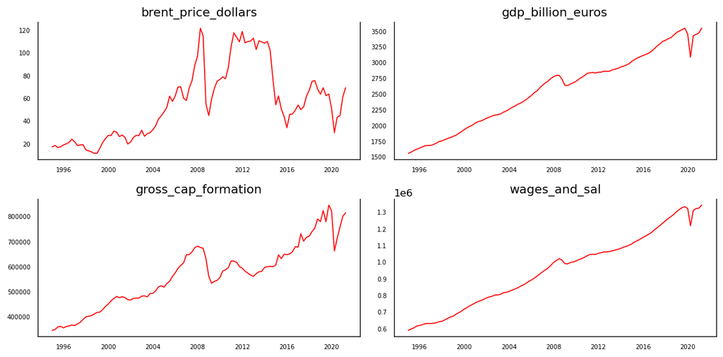

```python
# Plotting all the TimeSeries of the DataSet:
fig, axes = plt.subplots(nrows=2, ncols=2, dpi=120, figsize=(10,5))
for i, ax in enumerate(axes.flatten()):
    data = DATA[DATA.columns[i]]
    ax.plot(data, color='red', linewidth=1) # Decorations
    ax.set_title(DATA.columns[i])
    ax.xaxis.set_ticks_position('none')
    ax.yaxis.set_ticks_position('none')
    ax.spines["top"].set_alpha(0)
    ax.tick_params(labelsize=6, width=3)

plt.tight_layout();
```

## 7: Granger's Causality Test

Granger's Causality test is here to test for the null hypothesis that the coefficients of past values in the regression equation is zero

```python
from statsmodels.tsa.stattools import grangercausalitytests
maxlag=12
test ='ssr_chi2test'

def grangers_causation_matrix(data, variables, test='ssr_chi2test', verbose=False):
    df = pd.DataFrame(np.zeros((len(variables), len(variables))), columns=variables, index=variables)
    for c in df.columns:
        for r in df.index:
            test_result = grangercausalitytests(data[[r, c]], maxlag=maxlag, verbose=False)
            p_values =[round(test_result[i+1][0][test][1],4)
                       for i in range(maxlag)]
            if verbose:
                print(f'Y = {r}, X = {c}, P Values = {p_values}')
            min_p_value = np.min(p_values)
            df.loc[r, c]= min_p_value
    df.columns =[var +'_x'for var in variables]
    df.index =[var +'_y'for var in variables]
    return df

grangers_causation_matrix(DATA, variables = DATA.columns)
```

|  | brent_price_dollars_x | gdp_billion_euros_x | gross_cap_formation_x | wages_and_sal_x |
| --- | --- | --- | --- | --- |
| brent_price_dollars_y | 1.0000 | 0.2126 | 0.0498 | 0.0752 |
| gdp_billion_euros_y | 0.0342 | 1.0000 | 0.0000 | 0.0000 |
| gross_cap_formation_y | 0.0076 | 0.0000 | 1.0000 | 0.0000 |
| wages_and_sal_y | 0.0120 | 0.0000 | 0.0000 | 1.0000 |

## 8: Making our Data Stationary

In order to pass our Time Series into a VAR model, they should be stationary, i.e. differentiated (or else) until they become so. The next section makes those modifications to the Data before checking for the stationarity of the newly created Time Series to ensure they are fit to be passed into a VAR model. As a complement, it includes data Visualization of the Data Set and the split between Training and Testing Datathat will be useful later in the implementation of the model.

### 8.1: Split between Training and Testing Data

```python
nobs = 4
df_train, df_test = DATA[0:-nobs], DATA[-nobs:]

# Check size
print(df_train.shape)
print(df_test.shape)
```

```
(102, 4)
(4, 4)
```

### 8.2 : Stationarisation Modifications & Plotting

```python
## Stationarity implementation for each TimeSeries:

#Duplicating our original DataSet to further stabilize it:
DATA_StableAll = df_train.copy()

#We compute the log of Brent in order to stabilize it for further analysis and add column to dataset:

DATA_StableAll['brent_dollars_diff'] = DATA_StableAll.brent_price_dollars.diff()
DATA_StableAll['gdp_log'] = np.log(DATA_StableAll.gdp_billion_euros)
DATA_StableAll['gdp_log_diff'] = DATA_StableAll.gdp_log.diff()
DATA_StableAll['gdp_log_diff_two'] = DATA_StableAll.gdp_log_diff.diff()
DATA_StableAll['cap_formation_diff'] = DATA_StableAll.gross_cap_formation.diff()
DATA_StableAll['cap_formation_diff_two'] = DATA_StableAll.cap_formation_diff.diff()
DATA_StableAll['wages_log'] = np.log(DATA_StableAll.wages_and_sal)
DATA_StableAll['wages_log_diff'] = DATA_StableAll.wages_log.diff()
DATA_StableAll['wages_log_diff_two'] = DATA_StableAll.wages_log_diff.diff()

DATA_Stable = DATA_StableAll.copy()
DATA_Stable.dropna(inplace=True)

#We drop the columns from the orgiginal Dataset in order to keep the stabilized ones
DATA_Stable.drop(['brent_price_dollars', 'gdp_billion_euros', 'gross_cap_formation', 'cap_formation_diff', 'wages_and_sal', 'gdp_log', 'gdp_log_diff', 'wages_log', 'wages_log_diff'], axis=1, inplace=True)
```

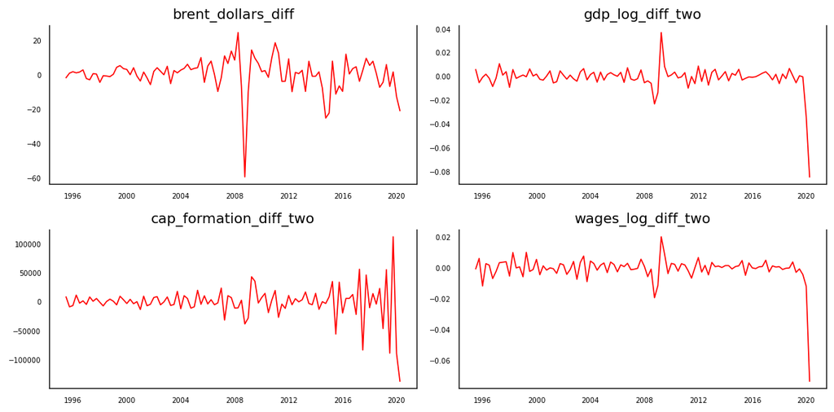

```python
# Plotting all the TimeSeries of the stabilized DataSet:
fig, axes = plt.subplots(nrows=2, ncols=2, dpi=120, figsize=(10,5))
for i, ax in enumerate(axes.flatten()):
    data = DATA_Stable[DATA_Stable.columns[i]]
    ax.plot(data, color='red', linewidth=1) # Decorations
    ax.set_title(DATA_Stable.columns[i])
    ax.xaxis.set_ticks_position('none')
    ax.yaxis.set_ticks_position('none')
    ax.spines["top"].set_alpha(0)
    ax.tick_params(labelsize=6, width=3)

plt.tight_layout();
```

### 8.3: Stationarity tests

```python
#Perform ADFuller to test for Stationarity and print report

def adfuller_test(series, signif=0.05, name='', verbose=False):
    r = adfuller(series, autolag='AIC')
    output = {'test_statistic':round(r[0], 4), 'pvalue':round(r[1], 4), 'n_lags':round(r[2], 4), 'n_obs':r[3]}
    p_value = output['pvalue']
    def adjust(val, length= 6): return str(val).ljust(length)

    # Print Summary
    print(f'    Augmented Dickey-Fuller Test on "{name}"', "\n   ", '-'*47)
    print(f' Null Hypothesis: Data has unit root. Non-Stationary.')
    print(f' Significance Level    = {signif}')
    print(f' Test Statistic        = {output["test_statistic"]}')
    print(f' No. Lags Chosen       = {output["n_lags"]}')

    for key,val in r[4].items():
        print(f' Critical value {adjust(key)} = {round(val, 3)}')

    if p_value <= signif:
        print(f" => P-Value = {p_value}. Rejecting Null Hypothesis.")
        print(f" => Series is Stationary.")
    else:
        print(f" => P-Value = {p_value}. Weak evidence to reject the Null Hypothesis.")
        print(f" => Series is Non-Stationary.")

# ADF Test on each column
for name, column in DATA_Stable.iteritems():
    adfuller_test(column, name=column.name)
    print('\n')
```

```
    Augmented Dickey-Fuller Test on "brent_dollars_diff"
    -----------------------------------------------
 Null Hypothesis: Data has unit root. Non-Stationary.
 Significance Level    = 0.05
 Test Statistic        = -7.4013
 No. Lags Chosen       = 1
 Critical value 1%     = -3.499
 Critical value 5%     = -2.892
 Critical value 10%    = -2.583
 => P-Value = 0.0. Rejecting Null Hypothesis.
 => Series is Stationary.


    Augmented Dickey-Fuller Test on "gdp_log_diff_two"
    -----------------------------------------------
 Null Hypothesis: Data has unit root. Non-Stationary.
 Significance Level    = 0.05
 Test Statistic        = -3.1141
 No. Lags Chosen       = 0
 Critical value 1%     = -3.498
 Critical value 5%     = -2.891
 Critical value 10%    = -2.583
 => P-Value = 0.0255. Rejecting Null Hypothesis.
 => Series is Stationary.


    Augmented Dickey-Fuller Test on "cap_formation_diff_two"
    -----------------------------------------------
 Null Hypothesis: Data has unit root. Non-Stationary.
 Significance Level    = 0.05
 Test Statistic        = -4.3408
 No. Lags Chosen       = 8
 Critical value 1%     = -3.504
 Critical value 5%     = -2.894
 Critical value 10%    = -2.584
 => P-Value = 0.0004. Rejecting Null Hypothesis.
 => Series is Stationary.


    Augmented Dickey-Fuller Test on "wages_log_diff_two"
    -----------------------------------------------
 Null Hypothesis: Data has unit root. Non-Stationary.
 Significance Level    = 0.05
 Test Statistic        = -4.3253
 No. Lags Chosen       = 0
 Critical value 1%     = -3.498
 Critical value 5%     = -2.891
 Critical value 10%    = -2.583
 => P-Value = 0.0004. Rejecting Null Hypothesis.
 => Series is Stationary.
```

## 9: VAR Modeling

First, the order of the VAR should be selected by iteratively increasing orders of VAR model and picking the order that gives the smallest AIC stat.

### 9.1: Order Selection

```python
model = VAR(DATA_Stable)
for i in [1,2,3,4,5,6,7,8,9]:
    result = model.fit(i)
    print('Lag Order =', i)
    print('AIC : ', result.aic)
    print('BIC : ', result.bic)
    print('FPE : ', result.fpe)
    print('HQIC: ', result.hqic, '\n')
```

```
Lag Order = 1
AIC :  2.9666746868885108
BIC :  3.490941323279337
FPE :  19.433895851847122
HQIC:  3.178793813432098

Lag Order = 2
AIC :  2.649387144685262
BIC :  3.598967034809146
FPE :  14.174762945511993
HQIC:  3.0334726234034495

Lag Order = 3
AIC :  2.797340321629372
BIC :  4.177597753404381
FPE :  16.507744608058584
HQIC:  3.355448840742432

Lag Order = 4
AIC :  2.8800110401214494
BIC :  4.6964243424111665
FPE :  18.08538653541439
HQIC:  3.6142349767117015

Lag Order = 5
AIC :  2.83431924006649
BIC :  5.092484070534336
FPE :  17.53148801148829
HQIC:  3.7467872501092256

Lag Order = 6
AIC :  3.0588478111626447
BIC :  5.764480558258394
FPE :  22.449227207148976
HQIC:  4.151725410759756

Lag Order = 7
AIC :  3.128129545674718
BIC :  6.28707084896265
FPE :  24.87983746904727
HQIC:  4.403619680672128

Lag Order = 8
AIC :  3.192246073485865
BIC :  6.810464466643184
FPE :  27.82085807065588
HQIC:  4.6525896742880155

Lag Order = 9
AIC :  3.1519875985349457
BIC :  7.235583279463448
FPE :  28.543385134936933
HQIC:  4.799464116517107
```

The best candidate for lag order seems tp be 2 here, which we check with the following, aletrnative method / formula :

```python
x = model.select_order(maxlags=12)
x.summary()
```

VAR Order Selection (* highlights the minimums)

|  | AIC | BIC | FPE | HQIC |
| --- | --- | --- | --- | --- |
| 0 | 4.656 | 4.769 | 105.2 | 4.702 |
| 1 | 3.121 | 3.684* | 22.68 | 3.348 |
| 2 | 2.779* | 3.793 | 16.16* | 3.188* |
| 3 | 2.958 | 4.421 | 19.42 | 3.547 |
| 4 | 3.061 | 4.976 | 21.78 | 3.833 |
| 5 | 2.951 | 5.316 | 19.86 | 3.904 |
| 6 | 3.175 | 5.990 | 25.52 | 4.309 |
| 7 | 3.177 | 6.442 | 26.55 | 4.492 |
| 8 | 3.301 | 7.017 | 31.67 | 4.799 |
| 9 | 3.204 | 7.370 | 30.75 | 4.882 |
| 10 | 3.296 | 7.912 | 36.86 | 5.156 |
| 11 | 3.255 | 8.323 | 39.69 | 5.297 |
| 12 | 3.301 | 8.819 | 48.05 | 5.524 |

##### Conclusion : The order of our VAR Model should be 2.

### 9.1 Training the VAR Model of order 2

As we have selected the order of the model, we then procede to train it as follows.

```python
model_fitted = model.fit(2)
model_fitted.summary()
```

```
  Summary of Regression Results
==================================
Model:                         VAR
Method:                        OLS
Date:           Mon, 13, Dec, 2021
Time:                     22:07:00
--------------------------------------------------------------------
No. of Equations:         4.00000    BIC:                    3.59897
Nobs:                     98.0000    HQIC:                   3.03347
Log likelihood:          -650.044    FPE:                    14.1748
AIC:                      2.64939    Det(Omega_mle):         9.97436
--------------------------------------------------------------------
Results for equation brent_dollars_diff
============================================================================================
                               coefficient       std. error           t-stat            prob
--------------------------------------------------------------------------------------------
const                             0.344658         0.915742            0.376           0.707
L1.brent_dollars_diff             0.361711         0.111025            3.258           0.001
L1.gdp_log_diff_two             529.728230       238.240834            2.223           0.026
L1.cap_formation_diff_two        -0.000138         0.000068           -2.022           0.043
L1.wages_log_diff_two          -395.637481       349.144277           -1.133           0.257
L2.brent_dollars_diff            -0.353660         0.109618           -3.226           0.001
L2.gdp_log_diff_two             405.495579       289.401423            1.401           0.161
L2.cap_formation_diff_two        -0.000051         0.000071           -0.713           0.476
L2.wages_log_diff_two           123.365491       332.805936            0.371           0.711
============================================================================================

Results for equation gdp_log_diff_two
============================================================================================
                               coefficient       std. error           t-stat            prob
--------------------------------------------------------------------------------------------
const                            -0.000832         0.000994           -0.837           0.403
L1.brent_dollars_diff             0.000184         0.000121            1.528           0.127
L1.gdp_log_diff_two               0.897412         0.258606            3.470           0.001
L1.cap_formation_diff_two        -0.000000         0.000000           -3.013           0.003
L1.wages_log_diff_two            -0.564282         0.378989           -1.489           0.137
L2.brent_dollars_diff            -0.000265         0.000119           -2.224           0.026
L2.gdp_log_diff_two               0.549191         0.314140            1.748           0.080
L2.cap_formation_diff_two        -0.000000         0.000000           -2.911           0.004
L2.wages_log_diff_two            -0.244262         0.361254           -0.676           0.499
```

[output cut: 23 more lines]

```
L1.gdp_log_diff_two               1.166101         0.183009            6.372           0.000
L1.cap_formation_diff_two        -0.000000         0.000000           -2.728           0.006
L1.wages_log_diff_two            -1.104743         0.268201           -4.119           0.000
L2.brent_dollars_diff            -0.000154         0.000084           -1.825           0.068
L2.gdp_log_diff_two               0.602107         0.222309            2.708           0.007
L2.cap_formation_diff_two        -0.000000         0.000000           -3.339           0.001
L2.wages_log_diff_two            -0.434522         0.255650           -1.700           0.089
============================================================================================

Correlation matrix of residuals
                          brent_dollars_diff  gdp_log_diff_two  cap_formation_diff_two  wages_log_diff_two
brent_dollars_diff                  1.000000          0.262583                0.225019            0.334588
gdp_log_diff_two                    0.262583          1.000000                0.629911            0.912459
cap_formation_diff_two              0.225019          0.629911                1.000000            0.568045
wages_log_diff_two                  0.334588          0.912459                0.568045            1.000000
```

### 9.2: Durbin Watson check for serial correlation of residuals

The following statistic is to be read as follows : the closer to two, there is no significant serial correlation. If there was, it would mean there are patterns in the time series still left to be explained by the model.

```python
from statsmodels.stats.stattools import durbin_watson
out = durbin_watson(model_fitted.resid)

for col, val in zip(DATA_Stable.columns, out):
    print(col, ':', round(val, 2))
```

```
brent_dollars_diff : 1.9
gdp_log_diff_two : 1.63
cap_formation_diff_two : 1.94
wages_log_diff_two : 1.54
```

### 9.3 Forecasting the VAR Model

After having checked the exhaustivity of the model thanks to the Durbin Watson stat, we can proceed to forecasting the model.

```python
# Get the lag order
lag_order = model_fitted.k_ar
print(lag_order)  #> 3

# Input data for forecasting
forecast_input = DATA_Stable.values[-lag_order:]
forecast_input
```

```
2
```

```
array([[-1.29700000e+01, -3.38358047e-02, -8.93155000e+04,
        -1.22188705e-02],
       [-2.10966667e+01, -8.45053199e-02, -1.36825200e+05,
        -7.37487048e-02]])
```

```python
# Forecast
fc = model_fitted.forecast(y=forecast_input, steps=nobs)
df_forecast = pd.DataFrame(fc, index=DATA.index[-nobs:], columns=DATA.columns + '_fc')
df_forecast
```

| newdate | brent_price_dollars_fc | gdp_billion_euros_fc | gross_cap_formation_fc | wages_and_sal_fc |
| --- | --- | --- | --- | --- |
| 2020-07-01 | -10.058143 | -0.000425 | -184.420378 | 0.001761 |
| 2020-10-01 | -33.168800 | 0.003878 | -19220.457920 | 0.004683 |
| 2021-01-01 | -5.180299 | 0.000240 | 27639.158999 | -0.003265 |
| 2021-04-01 | 10.918291 | 0.008160 | -7087.026434 | 0.007367 |

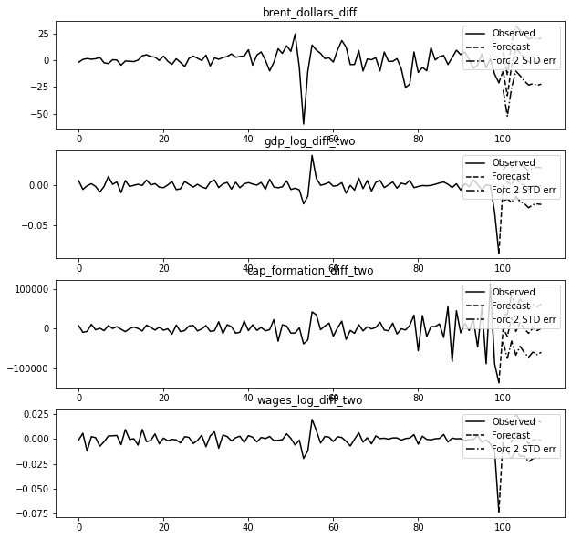

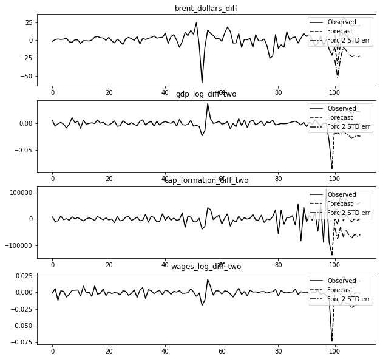

```python
model_fitted.plot_forecast(10)
```

This forecat is generated on the scale of the training data generated by the model. We will therefore need to invert (i.e. de-difference in most cases to retreive the correct forecast).

```python
df_fc = df_forecast.copy()
ToStabDATA = DATA_StableAll[-4:]
# df['reverse_diff'] = df['Age'].shift(1) + df['Age_diff']

# Re_stabilizing Brent Price in dollars :
brent, brent_diff = ToStabDATA['brent_price_dollars'].iloc[0], df_fc['brent_price_dollars_fc'].iloc[1:]
df_fc['brent_dollar_fc_OK'] = np.r_[brent, brent_diff].cumsum().astype(float)
df_fc

# Re_stabilizing Wages and Salaries :
wag_diff, wag_log_diff2 = ToStabDATA['wages_log_diff'].iloc[0], df_fc['wages_and_sal_fc'].iloc[1:]
df_fc['wag_log_diff_step'] = np.r_[wag_diff, wag_log_diff2].cumsum().astype(float)
wag_log, wag_log_diff = ToStabDATA['wages_log'].iloc[0], df_fc['wag_log_diff_step'].iloc[1:]
df_fc['wag_log_step'] = np.r_[wag_log, wag_log_diff].cumsum().astype(float)
df_fc['wage_fc_OK'] = np.exp(df_fc.wag_log_step)

# Re_stabilizing EU27 GDP :
gdp_log_diff, gdp_log_diff2 = ToStabDATA['gdp_log_diff'].iloc[0], df_fc['gdp_billion_euros_fc'].iloc[1:]
df_fc['gdp_log_diff_step'] = np.r_[gdp_log_diff, gdp_log_diff2].cumsum().astype(float)
gdp_log, gdp_log_diff = ToStabDATA['gdp_log'].iloc[0], df_fc['gdp_log_diff_step'].iloc[1:]
df_fc['gdp_log_step'] = np.r_[gdp_log, gdp_log_diff].cumsum().astype(float)
df_fc['gdp_fc_OK'] = np.exp(df_fc.gdp_log_step)

# Re_stabilizing Capital Formation :
cap_diff, cap_diff2 = ToStabDATA['cap_formation_diff'].iloc[0], df_fc['gross_cap_formation_fc'].iloc[1:]
df_fc['cap_fc_diff_step'] = np.r_[cap_diff, cap_diff2].cumsum().astype(float)
cap_ok, cap_diff = ToStabDATA['gross_cap_formation'].iloc[0], df_fc['cap_fc_diff_step'].iloc[1:]
df_fc['cap_fc_OK'] = np.r_[cap_ok, cap_diff].cumsum().astype(float)
```

```python
# Cleaning of the foecasted Data to resemble the original columns of our Dataset :
clean_forecast = df_fc[['brent_dollar_fc_OK', 'gdp_fc_OK', 'cap_fc_OK', 'wage_fc_OK']]
clean_forecast.rename(columns={'cap_fc_OK':'gross_cap_formation', 'gdp_fc_OK':'gdp_billion_euros', 'brent_dollar_fc_OK':'brent_price_dollars', 'wage_fc_OK':'wages_and_sal'}, inplace=True)
clean_forecast
```

| newdate | brent_price_dollars | gdp_billion_euros | gross_cap_formation | wages_and_sal |
| --- | --- | --- | --- | --- |
| 2020-07-01 | 61.930000 | 3518.557200 | 777231.800000 | 1.325817e+06 |
| 2020-10-01 | 28.761200 | 3556.434611 | 713300.942080 | 1.343810e+06 |
| 2021-01-01 | 23.580901 | 3595.582719 | 677009.243160 | 1.357607e+06 |
| 2021-04-01 | 34.499191 | 3664.947407 | 633630.517805 | 1.381687e+06 |

```python
df_test
```

| newdate | brent_price_dollars | gdp_billion_euros | gross_cap_formation | wages_and_sal |
| --- | --- | --- | --- | --- |
| 2020-07-01 | 42.963333 | 3421.1678 | 711445.7 | 1308421.2 |
| 2020-10-01 | 44.290000 | 3440.4539 | 756038.7 | 1320361.5 |
| 2021-01-01 | 60.820000 | 3463.5930 | 799003.5 | 1322619.2 |
| 2021-04-01 | 68.833333 | 3541.0934 | 812470.6 | 1340955.9 |

### 9.4 : Plotting Forecast vs. actual Data

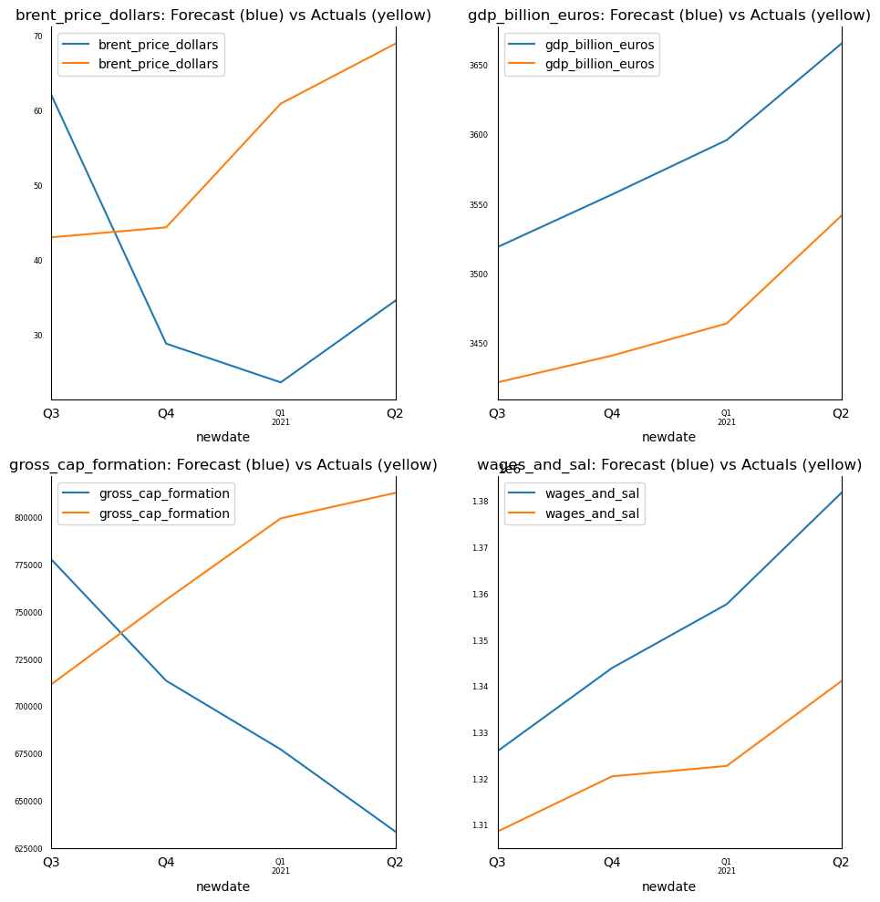

```python
fig, axes = plt.subplots(nrows=2, ncols=2, dpi=100, figsize=(10,10))
for i, (col,ax) in enumerate(zip(clean_forecast.columns, axes.flatten())):
    clean_forecast[col].plot(legend=True, ax=ax).autoscale(axis='x',tight=True)
    df_test[col].plot(legend=True, ax=ax);
    ax.set_title(col + ": Forecast (blue) vs Actuals (yellow)")
    ax.xaxis.set_ticks_position('none')
    ax.yaxis.set_ticks_position('none')
    ax.spines["top"].set_alpha(0)
    ax.tick_params(labelsize=6)

plt.tight_layout();
```

```python
def adjust(val, length= 4): return str(val).ljust(length)

from statsmodels.tsa.stattools import acf
def forecast_accuracy(forecast, actual):
    mape = np.mean(np.abs(forecast - actual)/np.abs(actual))  # MAPE
    me = np.mean(forecast - actual)             # ME
    mae = np.mean(np.abs(forecast - actual))    # MAE
    mpe = np.mean((forecast - actual)/actual)   # MPE
    rmse = np.mean((forecast - actual)**2)**.5  # RMSE
    corr = np.corrcoef(forecast, actual)[0,1]   # corr
    mins = np.amin(np.hstack([forecast[:,None],
                              actual[:,None]]), axis=1)
    maxs = np.amax(np.hstack([forecast[:,None],
                              actual[:,None]]), axis=1)
    minmax = 1 - np.mean(mins/maxs)             # minmax
    return({'mape':mape, 'me':me, 'mae': mae,
            'mpe': mpe, 'rmse':rmse, 'corr':corr, 'minmax':minmax})

print('Forecast Accuracy of: Brent Oil Prices')
accuracy_prod = forecast_accuracy(clean_forecast['brent_price_dollars'].values, df_test['brent_price_dollars'])
for k, v in accuracy_prod.items():
    print(adjust(k), ': ', round(v,4))

print('\nForecast Accuracy of: EU27 GDP')
accuracy_prod = forecast_accuracy(clean_forecast['gdp_billion_euros'].values, df_test['gdp_billion_euros'])
for k, v in accuracy_prod.items():
    print(adjust(k), ': ', round(v,4))

print('\nForecast Accuracy of: Wages and Salaries')
accuracy_prod = forecast_accuracy(clean_forecast['wages_and_sal'].values, df_test['wages_and_sal'])
for k, v in accuracy_prod.items():
    print(adjust(k), ': ', round(v,4))

print('\nForecast Accuracy of: Gross Capital Formation')
accuracy_prod = forecast_accuracy(clean_forecast['gross_cap_formation'].values, df_test['gross_cap_formation'])
for k, v in accuracy_prod.items():
    print(adjust(k), ': ', round(v,4))
```

```
Forecast Accuracy of: Brent Oil Prices
mape :  0.4758
me   :  -17.0338
mae  :  26.5172
mpe  :  -0.2551
rmse :  28.1357
corr :  -0.4984
minmax :  0.442

Forecast Accuracy of: EU27 GDP
mape :  0.0338
me   :  117.3035
mae  :  117.3035
mpe  :  0.0338
rmse :  118.0014
corr :  0.9816
minmax :  0.0327

Forecast Accuracy of: Wages and Salaries
mape :  0.022
me   :  29140.5914
mae  :  29140.5914
mpe  :  0.022
rmse :  30559.5869
corr :  0.9833
minmax :  0.0215

Forecast Accuracy of: Gross Capital Formation
mape :  0.1304
me   :  -69446.4992
mae  :  102339.5492
mpe  :  -0.0842
rmse :  115131.1216
corr :  -0.9834
minmax :  0.1285
```

## 10. Final Statistical tests on the VAR Model :

### 10.1 Impulse Response Analysis :

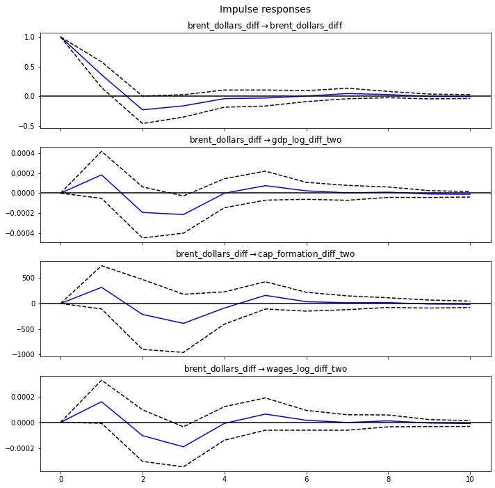

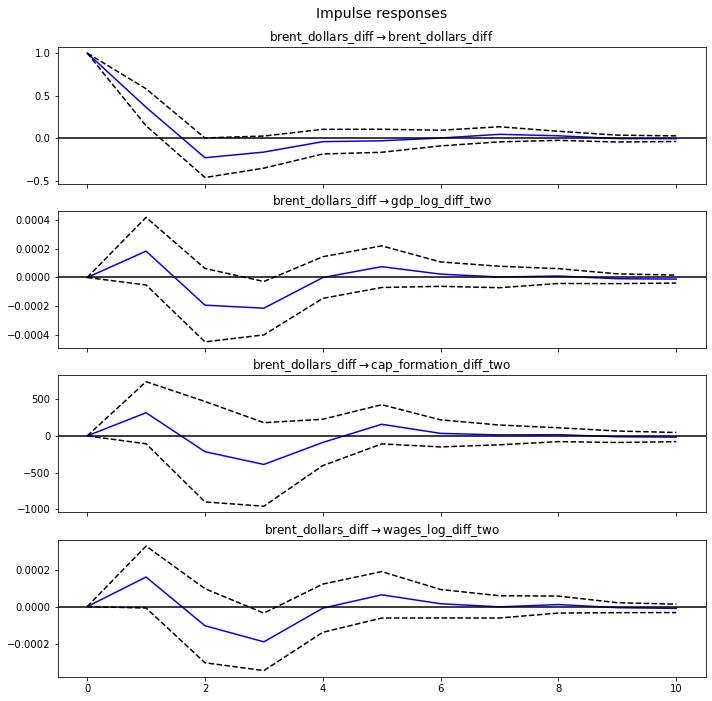

```python
from statsmodels.tsa.vector_ar.irf import IRAnalysis
irf = model_fitted.irf(10)
irf.plot(impulse='brent_dollars_diff')
```

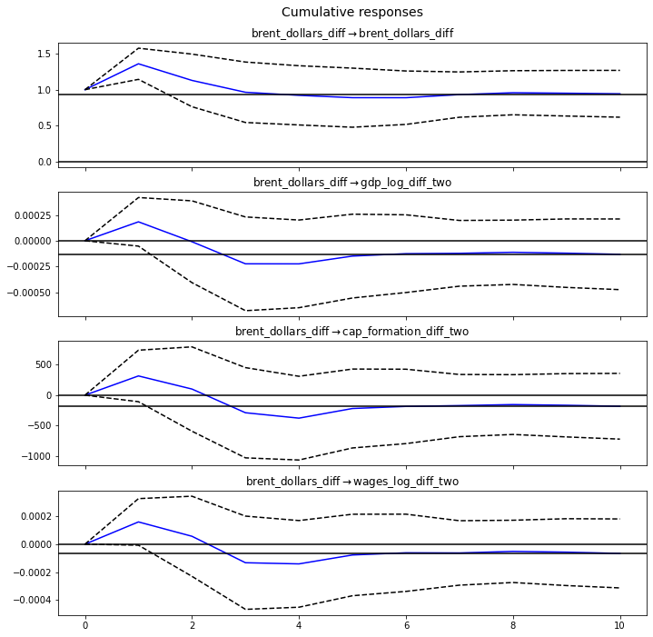

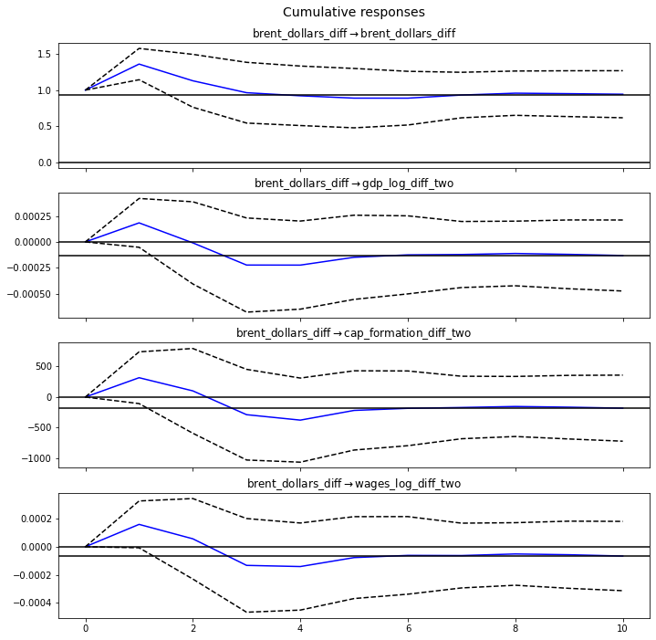

```python
#Impulse Response Cumulative effects :

irf.plot_cum_effects(impulse='brent_dollars_diff')
```

### 10.2 Forecast Error Variance Decomposition :

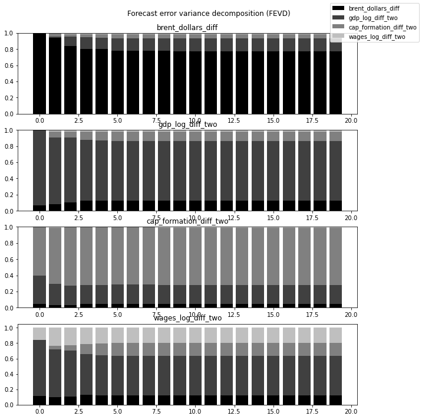

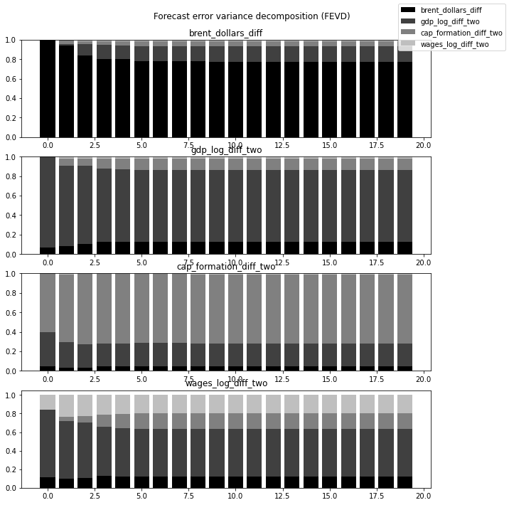

```python
fevd = model_fitted.fevd(5)
model_fitted.fevd(20).plot()
```